# UQ MATH2504 Programming of Simulation, Analysis, and Learning Systems (Semester 2 2025)

[Main MATH2504 Page](https://courses.smp.uq.edu.au/MATH2504/)

Unit 1 | Unit 2 | Unit 3 | Unit 4 | Unit 5 | Unit 6 | Unit 7 | Unit 8

# Unit 8: Working with heterogenous datasets and a view towards machine learning

In this unit we learn how to deal with heterogenous datasets using data frames. We then explore basic concepts of machine learning. A deep dive into deep learning at UQ is in the [STAT3007 course](https://my.uq.edu.au/programs-courses/course.html?course_code=STAT3007). Theory of machine learning (and statistical learning) is also studied in STAT3006. Other aspects of applied statistics and data analysis are studied in STAT3500. Our purpose with this unit is just to touch the tip of the iceberg on issues of data analysis and machine learning. The Julia language knowledge acquired in the previous units should help.

# Databases

This course doesn't touch databases, a rich topic of its own. (Do not confuse the term database with data structures or data frames). A database is a system that stores information in an organized and flexible manner. Many databases are **relational databases** and this means that they are comprised of multiple data tables that can be used together. The most common language for dealing with such databases is SQL. It is not a general programming language but rather a language for querying, modifying, and managing databases. At UQ you can study more about databases in the [INFS2200 course](https://my.uq.edu.au/programs-courses/course.html?course_code=infs2200) as well as several other more advanced courses.

We now show you an example of database and a few things you may expect from SQL.

## Relations

A "relation" is a mathematical term for a set over *tuples* (or *named* tuples), and is a generalization of a function.

For example, consider the function $y = f(x)$. (The *names* here are $x$ and $y$). An equivalent relation $f$ can be constructed as a set of tuples of the form $(x, y)$. A particular tuple $(x, y)$ is in the relation $f$ if and only if $y = f(x)$.

Other things which are not strictly functions may be relations. For example, we can construct a relation of real numbers $(x, y)$ where $x = y^2$. Or, equivalently, $y = \pm\sqrt{x}$. Positive values of $x$ correspond to two values of $y$ (positive or negative square root). When $x$ equals zero, there is only one solution for $y$ (also zero). And for negative $x$ there are no real $y$ that satisfy the relation. Note that I say "relation" and not "function" here - functions are only a subset of relations.

Just like functions may have multiple inputs ($x = f(a, b, c)$), a relation may consist of tuples of any size (including zero!). And both functions and relations can exist over finite, discrete sets.

There are precisely two relations over tuples of size zero (i.e. $()$) - the empty relation, and the relation containing the empty tuple $()$. You can use this fact to build up a kind of boolean logic in the language of relations, where the empty relation is `false` and the relation containing $()$ is `true`.

Outside of mathematics, the kinds of relations normally modelled in databases are of the discrete, finite-sized variety. A relation over tuples $(a, b, c)$ is equivalent to table with three columns $a$, $b$ and $c$. In a *strictly* relational databases, the ordering of the rows is irrelevant, and you cannot have two identical rows in the database (though in practice many databases in use may also deal with "bags" rather than "sets" of tuples, where rows can be repeated). The fields $a$, $b$ and $c$ are drawn from their own set of possibilities, or *datatype*. For example, you might have `(name, birthdate, is_adult)` where `name` may be a string, `birthdate` may be a date, and `is_adult` may be a boolean.

| `name` | `birthdate` | `is_adult` |
| --- | --- | --- |
| `"Alice"` | `2003-05-13` | `true` |
| `"Bob"` | `2005-12-10` | `false` |
| `"Charlie"` | `2004-09-21` | `true` |

Note that the latter two colums of this particular relation are a function if we assume `is_adult` is defined in terms of age (and thus in terms of `birthdate`).

In many relations, there are uniqueness constraints - for example the `name` might identify each row uniquely, or there may be a specific `ID` column to deal with different people sharing the same name. Such unique constraints are called "keys" and the primary identifier that you might use to fetch a particular row is called the "primary key".

## Relational schema

A single relation is a restrictive way to model your data. However, by allowing multiple relations, we can capture the various sets of data in the system, and piece them together by their *relationships*.

For example, each person in the table above might be related to other things. They might have jobs, bank accounts, etc. Within a single business a person might be a customer, a supplier and an employee, and for different purposes we might want data associated with that person (e.g. their birthdate might relate to advertizing promotions to customers, payrates for employees, etc).

Generally, to make keeping track of data easy, in a relational database you would store that person *just once* and create relationships between that person and other things. That way, if something changes about that person, it only needs to be updated in one place, and data remains consistent everywhere.

Here is an example of a more complex example - an imagining of how *LinkedIn* might store their data in a relational database (taken from "Designing Data-Intensive Applications" by Martin Kleppmann).

[figure not shown]

## SQL

The most popular way to interact with relational data is with via a language called SQL (originally "SEQUEL", pronounced that way, backronymed to "structured query language").

The language is from 1973 and doesn't look like most other programming languages. With it, you declare a "query" and the database will find the best way to return the results. It is a form of [declarative programming](https://en.wikipedia.org/wiki/Declarative_programming). Here is an example of getting some columns of data from the `users` table:

```sql
SELECT user_id, first_name, last_name
FROM users
```

You can filter the rows via a `WHERE` clause. Let's say you knew the `user_id` for Bill Gates and you wanted just his data:

```sql
SELECT user_id, first_name, last_name
FROM users
WHERE user_id = 251
```

Data in different tables are related via the `JOIN` statement

```sql
SELECT users.user_id, first_name, last_name, organization
INNER JOIN positions ON positions.user_id = users.user_id
FROM users
```

Note we have to prefix the shared column names with the corresponding table (although in this case the difference is not particularly important, your query cannot be ambiguous).

But there is a problem here. This query would create a large amount of data, that the database would need to collect and send over the network to you. In the worst case, performing such a query could bring down a large system!

Generally, you have something more precise in mind. Like - which organizations has Bill Gates worked at?

```sql
SELECT users.user_id, first_name, last_name, organization
INNER JOIN positions ON positions.user_id = users.user_id
FROM users
WHERE users.user_id = 251
```

This will now return just two rows (for Microsoft, and the Bill & Melinda Gates Foundation), and is much less effort for the database, the network and the client. In real-world settings, complex joins could link data spanning dozens of tables.

There are several Julia libraries for interacting with SQL databases including the likes of LibPQ.jl allowing queries to be executed on a PostgreSQL database and the results returned as convenient Julia data structures. There's even an SQL REPL in [SQLRepl.jl](https://github.com/c42f/SQLREPL.jl) if you want to execute SQL queries interactively and mix them with variables from your normal Julia session.

We won't be writing SQL in this course but it is so pervasive in industry that is essential that you know that it exists and not to be afraid to use it! (It is a very useful and desirable skill!) All the relational data concepts expressed in SQL above also apply to in-memory data analysis using Julia and we show various examples of this next.

# Dataframes

Working with tabular data is a central part of data analysis (think Excel). Data has rows (observations) and columns (variables/features). Typically a row would be for an individual, or item, or event. Typically a column would be for attributes of the individual, properties of the events, etc. Variables can be numerical, categorical, strings, or even more complex entities (e.g. images, arrays or dictionaries).

You have already seen how to read and write from CSV files in Unit 3 where you also explored JSON files. You may recall using the `DataFrames.jl` package in that unit. We now take a deeper dive into the concept of dataframes.

We will use `athlete_events.csv` to show basic functionality of the [DataFrames.jl](https://dataframes.juliadata.org/stable/) and TypedTables.jl packages. In a sense these packages are alternatives. Seeing some functionality from each may be useful for gaining a general understanding of what to expect from such packages. If you work with Python, then using [pandas](https://pandas.pydata.org/) is the common alternative. Similarly if you work with the R language then the built-in dataframes are common.

## Basic data exploration

Whenever you receive a dataset, it takes some time to understand its contents. This process is generally known as "data exploration". To do so, we generally load (a subset of) the data from disk and do some basic analysis in a Jupyter notebook or at the REPL.

We were introduced to CSV files earlier in the course. Here's the first few lines of our file:

```julia
open("../data/athlete_events.csv") do io
    i = 0
    while i < 5
        println(readline(io))
        i += 1
    end
end
```

```
"ID","Name","Sex","Age","Height","Weight","Team","NOC","Games","Year","Seas
on","City","Sport","Event","Medal"
"1","A Dijiang","M",24,180,80,"China","CHN","1992 Summer",1992,"Summer","Ba
rcelona","Basketball","Basketball Men's Basketball",NA
"2","A Lamusi","M",23,170,60,"China","CHN","2012 Summer",2012,"Summer","Lon
don","Judo","Judo Men's Extra-Lightweight",NA
"3","Gunnar Nielsen Aaby","M",24,NA,NA,"Denmark","DEN","1920 Summer",1920,"
Summer","Antwerpen","Football","Football Men's Football",NA
"4","Edgar Lindenau Aabye","M",34,NA,NA,"Denmark/Sweden","DEN","1900 Summer
",1900,"Summer","Paris","Tug-Of-War","Tug-Of-War Men's Tug-Of-War","Gold"
```

The `do` syntax here injects a function which takes `io::IO` (an I/O stream for our file) into the first argument of the `open` function. It is syntax sugar. The `open` function is designed such that when the inner function returns or throws an error, `open` will automatically close the file to avoid resource leakage.

We can use the *CSV.jl* package to read the data and the *DataFrames.jl* package to hold the tabular data. We note in the above the appearance of `"NA"` for missing data, which we can use to help load the file.

```julia
using DataFrames, CSV
csv_file = CSV.File("../data/athlete_events.csv"; missingstring = "NA")
df = DataFrame(csv_file)
println("Data size: ", size(df))
println("Columns in the data: ", names(df))
```

```
Data size: (271116, 15)
Columns in the data: ["ID", "Name", "Sex", "Age", "Height", "Weight", "Team
", "NOC", "Games", "Year", "Season", "City", "Sport", "Event", "Medal"]
```

Since the data is large, we don't usually want to print it all. The `first` and `last` functions can be helpful:

```julia
first(df, 10)
```

10×15 DataFrame

| Row | ID Int64 | Name String | Sex String1 | Age Int64? | Height Int64? | Weight Float64? | Team String | NOC String3 | Games String15 | Year Int64 | Season String7 | City String31 | Sport String31 | Event String | Medal String7? |
| --- | --- | --- | --- | --- | --- | --- | --- | --- | --- | --- | --- | --- | --- | --- | --- |
| 1 | 1 | A Dijiang | M | 24 | 180 | 80.0 | China | CHN | 1992 Summer | 1992 | Summer | Barcelona | Basketball | Basketball Men's Basketball | missing |
| 2 | 2 | A Lamusi | M | 23 | 170 | 60.0 | China | CHN | 2012 Summer | 2012 | Summer | London | Judo | Judo Men's Extra-Lightweight | missing |
| 3 | 3 | Gunnar Nielsen Aaby | M | 24 | missing | missing | Denmark | DEN | 1920 Summer | 1920 | Summer | Antwerpen | Football | Football Men's Football | missing |
| 4 | 4 | Edgar Lindenau Aabye | M | 34 | missing | missing | Denmark/Sweden | DEN | 1900 Summer | 1900 | Summer | Paris | Tug-Of-War | Tug-Of-War Men's Tug-Of-War | Gold |
| 5 | 5 | Christine Jacoba Aaftink | F | 21 | 185 | 82.0 | Netherlands | NED | 1988 Winter | 1988 | Winter | Calgary | Speed Skating | Speed Skating Women's 500 metres | missing |
| 6 | 5 | Christine Jacoba Aaftink | F | 21 | 185 | 82.0 | Netherlands | NED | 1988 Winter | 1988 | Winter | Calgary | Speed Skating | Speed Skating Women's 1,000 metres | missing |
| 7 | 5 | Christine Jacoba Aaftink | F | 25 | 185 | 82.0 | Netherlands | NED | 1992 Winter | 1992 | Winter | Albertville | Speed Skating | Speed Skating Women's 500 metres | missing |
| 8 | 5 | Christine Jacoba Aaftink | F | 25 | 185 | 82.0 | Netherlands | NED | 1992 Winter | 1992 | Winter | Albertville | Speed Skating | Speed Skating Women's 1,000 metres | missing |
| 9 | 5 | Christine Jacoba Aaftink | F | 27 | 185 | 82.0 | Netherlands | NED | 1994 Winter | 1994 | Winter | Lillehammer | Speed Skating | Speed Skating Women's 500 metres | missing |
| 10 | 5 | Christine Jacoba Aaftink | F | 27 | 185 | 82.0 | Netherlands | NED | 1994 Winter | 1994 | Winter | Lillehammer | Speed Skating | Speed Skating Women's 1,000 metres | missing |

```julia
last(df, 10)
```

10×15 DataFrame

| Row | ID Int64 | Name String | Sex String1 | Age Int64? | Height Int64? | Weight Float64? | Team String | NOC String3 | Games String15 | Year Int64 | Season String7 | City String31 | Sport String31 | Event String | Medal String7? |
| --- | --- | --- | --- | --- | --- | --- | --- | --- | --- | --- | --- | --- | --- | --- | --- |
| 1 | 135565 | Fernando scar Zylberberg | M | 27 | 168 | 76.0 | Argentina | ARG | 2004 Summer | 2004 | Summer | Athina | Hockey | Hockey Men's Hockey | missing |
| 2 | 135566 | James Francis "Jim" Zylker | M | 21 | 175 | 75.0 | United States | USA | 1972 Summer | 1972 | Summer | Munich | Football | Football Men's Football | missing |
| 3 | 135567 | Aleksandr Viktorovich Zyuzin | M | 24 | 183 | 72.0 | Russia | RUS | 2000 Summer | 2000 | Summer | Sydney | Rowing | Rowing Men's Lightweight Coxless Fours | missing |
| 4 | 135567 | Aleksandr Viktorovich Zyuzin | M | 28 | 183 | 72.0 | Russia | RUS | 2004 Summer | 2004 | Summer | Athina | Rowing | Rowing Men's Lightweight Coxless Fours | missing |
| 5 | 135568 | Olga Igorevna Zyuzkova | F | 33 | 171 | 69.0 | Belarus | BLR | 2016 Summer | 2016 | Summer | Rio de Janeiro | Basketball | Basketball Women's Basketball | missing |
| 6 | 135569 | Andrzej ya | M | 29 | 179 | 89.0 | Poland-1 | POL | 1976 Winter | 1976 | Winter | Innsbruck | Luge | Luge Mixed (Men)'s Doubles | missing |
| 7 | 135570 | Piotr ya | M | 27 | 176 | 59.0 | Poland | POL | 2014 Winter | 2014 | Winter | Sochi | Ski Jumping | Ski Jumping Men's Large Hill, Individual | missing |
| 8 | 135570 | Piotr ya | M | 27 | 176 | 59.0 | Poland | POL | 2014 Winter | 2014 | Winter | Sochi | Ski Jumping | Ski Jumping Men's Large Hill, Team | missing |
| 9 | 135571 | Tomasz Ireneusz ya | M | 30 | 185 | 96.0 | Poland | POL | 1998 Winter | 1998 | Winter | Nagano | Bobsleigh | Bobsleigh Men's Four | missing |
| 10 | 135571 | Tomasz Ireneusz ya | M | 34 | 185 | 96.0 | Poland | POL | 2002 Winter | 2002 | Winter | Salt Lake City | Bobsleigh | Bobsleigh Men's Four | missing |

This dataset appears to be sorted by last name. Each row corresponds to an entrant to an event. The ID column identifies each unique athlete.

A `DataFrame` is indexed like a 2D container of rows and columns. The `:` symbol means "all".

```julia
df[1:10, :]
```

10×15 DataFrame

| Row | ID Int64 | Name String | Sex String1 | Age Int64? | Height Int64? | Weight Float64? | Team String | NOC String3 | Games String15 | Year Int64 | Season String7 | City String31 | Sport String31 | Event String | Medal String7? |
| --- | --- | --- | --- | --- | --- | --- | --- | --- | --- | --- | --- | --- | --- | --- | --- |
| 1 | 1 | A Dijiang | M | 24 | 180 | 80.0 | China | CHN | 1992 Summer | 1992 | Summer | Barcelona | Basketball | Basketball Men's Basketball | missing |
| 2 | 2 | A Lamusi | M | 23 | 170 | 60.0 | China | CHN | 2012 Summer | 2012 | Summer | London | Judo | Judo Men's Extra-Lightweight | missing |
| 3 | 3 | Gunnar Nielsen Aaby | M | 24 | missing | missing | Denmark | DEN | 1920 Summer | 1920 | Summer | Antwerpen | Football | Football Men's Football | missing |
| 4 | 4 | Edgar Lindenau Aabye | M | 34 | missing | missing | Denmark/Sweden | DEN | 1900 Summer | 1900 | Summer | Paris | Tug-Of-War | Tug-Of-War Men's Tug-Of-War | Gold |
| 5 | 5 | Christine Jacoba Aaftink | F | 21 | 185 | 82.0 | Netherlands | NED | 1988 Winter | 1988 | Winter | Calgary | Speed Skating | Speed Skating Women's 500 metres | missing |
| 6 | 5 | Christine Jacoba Aaftink | F | 21 | 185 | 82.0 | Netherlands | NED | 1988 Winter | 1988 | Winter | Calgary | Speed Skating | Speed Skating Women's 1,000 metres | missing |
| 7 | 5 | Christine Jacoba Aaftink | F | 25 | 185 | 82.0 | Netherlands | NED | 1992 Winter | 1992 | Winter | Albertville | Speed Skating | Speed Skating Women's 500 metres | missing |
| 8 | 5 | Christine Jacoba Aaftink | F | 25 | 185 | 82.0 | Netherlands | NED | 1992 Winter | 1992 | Winter | Albertville | Speed Skating | Speed Skating Women's 1,000 metres | missing |
| 9 | 5 | Christine Jacoba Aaftink | F | 27 | 185 | 82.0 | Netherlands | NED | 1994 Winter | 1994 | Winter | Lillehammer | Speed Skating | Speed Skating Women's 500 metres | missing |
| 10 | 5 | Christine Jacoba Aaftink | F | 27 | 185 | 82.0 | Netherlands | NED | 1994 Winter | 1994 | Winter | Lillehammer | Speed Skating | Speed Skating Women's 1,000 metres | missing |

Internally, a dataframe stores one vector of data per column. You can access any of them conveniently as "properties" with `.` syntax:

```julia
df.ID
```

```
271116-element Vector{Int64}:
      1
      2
      3
      4
      5
      5
      5
      5
      5
      5
      ⋮
 135566
 135567
 135567
 135568
 135569
 135570
 135570
 135571
 135571
```

```julia
df.Height
```

```
271116-element Vector{Union{Missing, Int64}}:
 180
 170
    missing
    missing
 185
 185
 185
 185
 185
 185
   ⋮
 175
 183
 183
 171
 179
 176
 176
 185
 185
```

As you can see from above, some data can be missing. How many heights are missing?

```julia
ismissing.(df.Height) |> count # Piping: `f(x) |> g` syntax means `g(f(x))`
```

```
60171
```

The `count` function counts the number of `true` values.

How many unique athletes are there?

```julia
unique(df.ID) |> length
```

```
135571
```

The `unique` operation has extra methods defined for `DataFrame`s. We can get the athlete data like so:

```julia
athlete_df = unique(df, :ID)
```

135571×15 DataFrame

135546 rows omitted

| Row | ID Int64 | Name String | Sex String1 | Age Int64? | Height Int64? | Weight Float64? | Team String | NOC String3 | Games String15 | Year Int64 | Season String7 | City String31 | Sport String31 | Event String | Medal String7? |
| --- | --- | --- | --- | --- | --- | --- | --- | --- | --- | --- | --- | --- | --- | --- | --- |
| 1 | 1 | A Dijiang | M | 24 | 180 | 80.0 | China | CHN | 1992 Summer | 1992 | Summer | Barcelona | Basketball | Basketball Men's Basketball | missing |
| 2 | 2 | A Lamusi | M | 23 | 170 | 60.0 | China | CHN | 2012 Summer | 2012 | Summer | London | Judo | Judo Men's Extra-Lightweight | missing |
| 3 | 3 | Gunnar Nielsen Aaby | M | 24 | missing | missing | Denmark | DEN | 1920 Summer | 1920 | Summer | Antwerpen | Football | Football Men's Football | missing |
| 4 | 4 | Edgar Lindenau Aabye | M | 34 | missing | missing | Denmark/Sweden | DEN | 1900 Summer | 1900 | Summer | Paris | Tug-Of-War | Tug-Of-War Men's Tug-Of-War | Gold |
| 5 | 5 | Christine Jacoba Aaftink | F | 21 | 185 | 82.0 | Netherlands | NED | 1988 Winter | 1988 | Winter | Calgary | Speed Skating | Speed Skating Women's 500 metres | missing |
| 6 | 6 | Per Knut Aaland | M | 31 | 188 | 75.0 | United States | USA | 1992 Winter | 1992 | Winter | Albertville | Cross Country Skiing | Cross Country Skiing Men's 10 kilometres | missing |
| 7 | 7 | John Aalberg | M | 31 | 183 | 72.0 | United States | USA | 1992 Winter | 1992 | Winter | Albertville | Cross Country Skiing | Cross Country Skiing Men's 10 kilometres | missing |
| 8 | 8 | Cornelia "Cor" Aalten (-Strannood) | F | 18 | 168 | missing | Netherlands | NED | 1932 Summer | 1932 | Summer | Los Angeles | Athletics | Athletics Women's 100 metres | missing |
| 9 | 9 | Antti Sami Aalto | M | 26 | 186 | 96.0 | Finland | FIN | 2002 Winter | 2002 | Winter | Salt Lake City | Ice Hockey | Ice Hockey Men's Ice Hockey | missing |
| 10 | 10 | Einar Ferdinand "Einari" Aalto | M | 26 | missing | missing | Finland | FIN | 1952 Summer | 1952 | Summer | Helsinki | Swimming | Swimming Men's 400 metres Freestyle | missing |
| 11 | 11 | Jorma Ilmari Aalto | M | 22 | 182 | 76.5 | Finland | FIN | 1980 Winter | 1980 | Winter | Lake Placid | Cross Country Skiing | Cross Country Skiing Men's 30 kilometres | missing |
| 12 | 12 | Jyri Tapani Aalto | M | 31 | 172 | 70.0 | Finland | FIN | 2000 Summer | 2000 | Summer | Sydney | Badminton | Badminton Men's Singles | missing |
| 13 | 13 | Minna Maarit Aalto | F | 30 | 159 | 55.5 | Finland | FIN | 1996 Summer | 1996 | Summer | Atlanta | Sailing | Sailing Women's Windsurfer | missing |
| ⋮ | ⋮ | ⋮ | ⋮ | ⋮ | ⋮ | ⋮ | ⋮ | ⋮ | ⋮ | ⋮ | ⋮ | ⋮ | ⋮ | ⋮ | ⋮ |
| 135560 | 135560 | Stavroula Zygouri | F | 36 | 171 | 63.0 | Greece | GRE | 2004 Summer | 2004 | Summer | Athina | Wrestling | Wrestling Women's Middleweight, Freestyle | missing |
| 135561 | 135561 | Frantiek Zyka | M | 26 | missing | missing | Czechoslovakia | TCH | 1928 Summer | 1928 | Summer | Amsterdam | Athletics | Athletics Men's Marathon | missing |
| 135562 | 135562 | Milan Zyka | M | 24 | 173 | 68.0 | Czechoslovakia | TCH | 1972 Summer | 1972 | Summer | Munich | Cycling | Cycling Men's Team Pursuit, 4,000 metres | missing |
| 135563 | 135563 | Olesya Nikolayevna Zykina | F | 19 | 171 | 64.0 | Russia | RUS | 2000 Summer | 2000 | Summer | Sydney | Athletics | Athletics Women's 4 x 400 metres Relay | Bronze |
| 135564 | 135564 | Yevgeny Aleksandrovich Zykov | M | 22 | 172 | 65.0 | Russia-1 | RUS | 2002 Winter | 2002 | Winter | Salt Lake City | Luge | Luge Mixed (Men)'s Doubles | missing |
| 135565 | 135565 | Fernando scar Zylberberg | M | 23 | 168 | 76.0 | Argentina | ARG | 2000 Summer | 2000 | Summer | Sydney | Hockey | Hockey Men's Hockey | missing |
| 135566 | 135566 | James Francis "Jim" Zylker | M | 21 | 175 | 75.0 | United States | USA | 1972 Summer | 1972 | Summer | Munich | Football | Football Men's Football | missing |
| 135567 | 135567 | Aleksandr Viktorovich Zyuzin | M | 24 | 183 | 72.0 | Russia | RUS | 2000 Summer | 2000 | Summer | Sydney | Rowing | Rowing Men's Lightweight Coxless Fours | missing |
| 135568 | 135568 | Olga Igorevna Zyuzkova | F | 33 | 171 | 69.0 | Belarus | BLR | 2016 Summer | 2016 | Summer | Rio de Janeiro | Basketball | Basketball Women's Basketball | missing |
| 135569 | 135569 | Andrzej ya | M | 29 | 179 | 89.0 | Poland-1 | POL | 1976 Winter | 1976 | Winter | Innsbruck | Luge | Luge Mixed (Men)'s Doubles | missing |
| 135570 | 135570 | Piotr ya | M | 27 | 176 | 59.0 | Poland | POL | 2014 Winter | 2014 | Winter | Sochi | Ski Jumping | Ski Jumping Men's Large Hill, Individual | missing |
| 135571 | 135571 | Tomasz Ireneusz ya | M | 30 | 185 | 96.0 | Poland | POL | 1998 Winter | 1998 | Winter | Nagano | Bobsleigh | Bobsleigh Men's Four | missing |

It keeps all columns of the first row containing each distinct ID, which will we take as representative (for their Sex, Height, Weight, etc).

## Simple analysis

Now we are becoming familiar with the dataset, we might like to see what insights we can gain. For example, let's see how many men and women have competed.

```julia
count(==("M"), athlete_df.Sex)  # `==(x)` creates a function `y -> y == x`
```

```
101590
```

```julia
count(==("F"), athlete_df.Sex)
```

```
33981
```

The `count` function is useful, but this gets tiresome for many "groups" of data. The SplitApplyCombine.jl package contains useful functions for grouping data.

```julia
using SplitApplyCombine

groupcount(athlete_df.Sex)
```

```
2-element Dictionaries.Dictionary{String1, Int64}:
 String1("M") │ 101590
 String1("F") │ 33981
```

Which allows us to explore larger sets of groupings:

```julia
# How many athletes by country
team_sizes = groupcount(athlete_df.Team)
```

```
1013-element Dictionaries.Dictionary{String, Int64}:
          "China" │ 2589
        "Denmark" │ 1840
 "Denmark/Sweden" │ 5
    "Netherlands" │ 2849
  "United States" │ 9051
        "Finland" │ 2271
         "Norway" │ 2029
        "Romania" │ 1735
        "Estonia" │ 336
         "France" │ 5717
                ⋮ │ ⋮
       "Sjovinge" │ 2
    "Brandenburg" │ 1
        "Struten" │ 1
       "Freia-19" │ 1
   "Luxembourg-1" │ 1
      "Sea Dog-2" │ 2
          "Mainz" │ 1
        "Druzhba" │ 1
        "China-3" │ 2
```

One of the most powerful tricks in data analysis is to sort your data.

```julia
sort(team_sizes)
```

```
1013-element Dictionaries.Dictionary{String, Int64}:
     "Nigeria-2" │ 1
 "Puerto Rico-2" │ 1
          "Lett" │ 1
       "Breslau" │ 1
  "Carabinier-5" │ 1
      "Evita VI" │ 1
      "Konstanz" │ 1
          "Nora" │ 1
          "Inca" │ 1
         "Snude" │ 1
               ⋮ │ ⋮
        "Sweden" │ 3598
     "Australia" │ 3731
         "Japan" │ 3990
       "Germany" │ 4318
        "Canada" │ 4504
         "Italy" │ 4650
 "Great Britain" │ 5706
        "France" │ 5717
 "United States" │ 9051
```

Note that `groupcount` is a specialization of the more flexible `group(keys, values)` function:

```julia
group(athlete_df.Team, athlete_df.Name)
```

```
1013-element Dictionaries.Dictionary{String, Vector{String}}:
          "China" │ ["A Dijiang", "A Lamusi", "Abudoureheman", "Ai Linuer",
 "Ai…
        "Denmark" │ ["Gunnar Nielsen Aaby", "Otto Mnsted Acthon", "Jesper A
gerg…
 "Denmark/Sweden" │ ["Edgar Lindenau Aabye", "August Nilsson", "Gustaf Fred
rik …
    "Netherlands" │ ["Christine Jacoba Aaftink", "Cornelia \"Cor\" Aalten (
-Str…
  "United States" │ ["Per Knut Aaland", "John Aalberg", "Stephen Anthony Ab
as",…
        "Finland" │ ["Antti Sami Aalto", "Einar Ferdinand \"Einari\" Aalto"
, "J…
         "Norway" │ ["Kjetil Andr Aamodt", "Ragnhild Margrethe Aamodt", "Fr
itz …
        "Romania" │ ["Andreea Aanei", "Andrei Abraham", "Elisabeta Abrudean
u", …
        "Estonia" │ ["Evald rma (rman-)", "Meelis Aasme", "Moonika Aava", "
Arvi…
         "France" │ ["Jamale (Djamel-) Aarrass (Ahrass-)", "Patrick Abada",
 "Re…
                ⋮ │ ⋮
       "Sjovinge" │ ["Christian Vinge", "Bengt Gran Waller"]
    "Brandenburg" │ ["Erik Johannes Peter Ernst von Holst"]
        "Struten" │ ["Knut Astrup Wang"]
       "Freia-19" │ ["Georges Camille Warenhorst"]
   "Luxembourg-1" │ ["Gza Wertheim"]
      "Sea Dog-2" │ ["Thomas Douglas Wynn Weston", "Joseph Warwick Wright"]
          "Mainz" │ ["Erich Wichmann-Harbeck"]
        "Druzhba" │ ["Valentin Alekseyevich Zamotaykin"]
        "China-3" │ ["Zhang Dan", "Zhang Hao"]
```

Rather than acting at the level of vectors, you can group an entire `DataFrame` into a `GroupedDataFrame` with the `groupby` function provided by *DataFrames.jl*:

```julia
gdf = groupby(athlete_df, :Team)
```

**GroupedDataFrame with 1013 groups based on key: Team**

First Group (2589 rows): Team = "China"

2564 rows omitted

| Row | ID Int64 | Name String | Sex String1 | Age Int64? | Height Int64? | Weight Float64? | Team String | NOC String3 | Games String15 | Year Int64 | Season String7 | City String31 | Sport String31 | Event String | Medal String7? |
| --- | --- | --- | --- | --- | --- | --- | --- | --- | --- | --- | --- | --- | --- | --- | --- |
| 1 | 1 | A Dijiang | M | 24 | 180 | 80.0 | China | CHN | 1992 Summer | 1992 | Summer | Barcelona | Basketball | Basketball Men's Basketball | missing |
| 2 | 2 | A Lamusi | M | 23 | 170 | 60.0 | China | CHN | 2012 Summer | 2012 | Summer | London | Judo | Judo Men's Extra-Lightweight | missing |
| 3 | 602 | Abudoureheman | M | 22 | 182 | 75.0 | China | CHN | 2000 Summer | 2000 | Summer | Sydney | Boxing | Boxing Men's Middleweight | missing |
| 4 | 1463 | Ai Linuer | M | 25 | 160 | 62.0 | China | CHN | 2004 Summer | 2004 | Summer | Athina | Wrestling | Wrestling Men's Lightweight, Greco-Roman | missing |
| 5 | 1464 | Ai Yanhan | F | 14 | 168 | 54.0 | China | CHN | 2016 Summer | 2016 | Summer | Rio de Janeiro | Swimming | Swimming Women's 200 metres Freestyle | missing |
| 6 | 3605 | An Weijiang | M | 22 | 178 | 72.0 | China | CHN | 2006 Winter | 2006 | Winter | Torino | Speed Skating | Speed Skating Men's 500 metres | missing |
| 7 | 3610 | An Yulong | M | 19 | 173 | 70.0 | China | CHN | 1998 Winter | 1998 | Winter | Nagano | Short Track Speed Skating | Short Track Speed Skating Men's 500 metres | Silver |
| 8 | 3611 | An Zhongxin | F | 23 | 170 | 65.0 | China | CHN | 1996 Summer | 1996 | Summer | Atlanta | Softball | Softball Women's Softball | Silver |
| 9 | 4639 | Ao Changrong | M | 25 | 173 | 71.0 | China | CHN | 2008 Summer | 2008 | Summer | Beijing | Hockey | Hockey Men's Hockey | missing |
| 10 | 4641 | Ao Tegen | M | 21 | 181 | 90.0 | China | CHN | 1996 Summer | 1996 | Summer | Atlanta | Judo | Judo Men's Middleweight | missing |
| 11 | 6376 | Ba Dexin | M | 23 | 185 | 80.0 | China | CHN | 2014 Winter | 2014 | Winter | Sochi | Curling | Curling Men's Curling | missing |
| 12 | 6381 | Ba Yan | F | 21 | 183 | 78.0 | China | CHN | 1984 Summer | 1984 | Summer | Los Angeles | Basketball | Basketball Women's Basketball | Bronze |
| 13 | 6382 | Ba Yanchuan | M | 24 | 187 | 100.0 | China | CHN | 1996 Summer | 1996 | Summer | Atlanta | Wrestling | Wrestling Men's Heavyweight, Greco-Roman | missing |
| ⋮ | ⋮ | ⋮ | ⋮ | ⋮ | ⋮ | ⋮ | ⋮ | ⋮ | ⋮ | ⋮ | ⋮ | ⋮ | ⋮ | ⋮ | ⋮ |
| 2578 | 134870 | Zhu Zhifu | M | 25 | 179 | 72.0 | China | CHN | 2004 Summer | 2004 | Summer | Athina | Rowing | Rowing Men's Lightweight Double Sculls | missing |
| 2579 | 134872 | Zhuang Xiaoyan | F | 23 | 173 | 98.0 | China | CHN | 1992 Summer | 1992 | Summer | Barcelona | Judo | Judo Women's Heavyweight | Gold |
| 2580 | 134873 | Zhuang Yong | F | 16 | 172 | 68.0 | China | CHN | 1988 Summer | 1988 | Summer | Seoul | Swimming | Swimming Women's 100 metres Freestyle | Silver |
| 2581 | 135230 | Zong Xiangqing | M | 24 | 193 | 72.0 | China | CHN | 1984 Summer | 1984 | Summer | Los Angeles | Fencing | Fencing Men's epee, Individual | missing |
| 2582 | 135269 | Zou Kai | M | 20 | 158 | 55.0 | China | CHN | 2008 Summer | 2008 | Summer | Beijing | Gymnastics | Gymnastics Men's Individual All-Around | missing |
| 2583 | 135270 | Zou Shiming | M | 23 | 165 | 49.0 | China | CHN | 2004 Summer | 2004 | Summer | Athina | Boxing | Boxing Men's Light-Flyweight | Bronze |
| 2584 | 135271 | Zou Sixin | M | 25 | 178 | 76.0 | China | CHN | 1992 Summer | 1992 | Summer | Barcelona | Athletics | Athletics Men's Triple Jump | missing |
| 2585 | 135272 | Zou Wenzhi | M | missing | missing | missing | China | CHN | 1948 Summer | 1948 | Summer | London | Football | Football Men's Football | missing |
| 2586 | 135273 | Zou Yuchen | M | 20 | 203 | 107.0 | China | CHN | 2016 Summer | 2016 | Summer | Rio de Janeiro | Basketball | Basketball Men's Basketball | missing |
| 2587 | 135274 | Zou Zhenxian | M | 28 | 184 | 72.0 | China | CHN | 1984 Summer | 1984 | Summer | Los Angeles | Athletics | Athletics Men's Triple Jump | missing |
| 2588 | 135318 | Zu Lijun | M | 26 | 188 | 87.0 | China | CHN | 2016 Summer | 2016 | Summer | Rio de Janeiro | Swimming | Swimming Men's 10 kilometres Open Water | missing |
| 2589 | 135445 | Zuo Yue | M | 21 | 192 | 88.0 | China | CHN | 1984 Summer | 1984 | Summer | Los Angeles | Volleyball | Volleyball Men's Volleyball | missing |

⋮

Last Group (2 rows): Team = "China-3"

| Row | ID Int64 | Name String | Sex String1 | Age Int64? | Height Int64? | Weight Float64? | Team String | NOC String3 | Games String15 | Year Int64 | Season String7 | City String31 | Sport String31 | Event String | Medal String7? |
| --- | --- | --- | --- | --- | --- | --- | --- | --- | --- | --- | --- | --- | --- | --- | --- |
| 1 | 134439 | Zhang Dan | F | 16 | 167 | 48.0 | China-3 | CHN | 2002 Winter | 2002 | Winter | Salt Lake City | Figure Skating | Figure Skating Mixed Pairs | missing |
| 2 | 134461 | Zhang Hao | M | 17 | 181 | 72.0 | China-3 | CHN | 2002 Winter | 2002 | Winter | Salt Lake City | Figure Skating | Figure Skating Mixed Pairs | missing |

You can apply an operation to each group and bring the data together into a single `DataFrame` via the `combine` function.

```julia
combine(gdf, nrow => :Count)
```

1013×2 DataFrame

988 rows omitted

| Row | Team String | Count Int64 |
| --- | --- | --- |
| 1 | China | 2589 |
| 2 | Denmark | 1840 |
| 3 | Denmark/Sweden | 5 |
| 4 | Netherlands | 2849 |
| 5 | United States | 9051 |
| 6 | Finland | 2271 |
| 7 | Norway | 2029 |
| 8 | Romania | 1735 |
| 9 | Estonia | 336 |
| 10 | France | 5717 |
| 11 | Taifun | 5 |
| 12 | Morocco | 459 |
| 13 | Spain | 2576 |
| ⋮ | ⋮ | ⋮ |
| 1002 | Trintel II | 1 |
| 1003 | Springbok | 1 |
| 1004 | Monaco-1 | 1 |
| 1005 | Sjovinge | 2 |
| 1006 | Brandenburg | 1 |
| 1007 | Struten | 1 |
| 1008 | Freia-19 | 1 |
| 1009 | Luxembourg-1 | 1 |
| 1010 | Sea Dog-2 | 2 |
| 1011 | Mainz | 1 |
| 1012 | Druzhba | 1 |
| 1013 | China-3 | 2 |

The `nrow => :Count` syntax is a convenience provided by *Dataframes.jl*. We'll explain how it works below.

## Row- and column-based storage

What is a dataframe?

It is a data structure containing rows and columns. Internally it keeps each column of data as its own vector, which you can access as a property with `.`

```julia
athlete_df.Height
```

```
135571-element Vector{Union{Missing, Int64}}:
 180
 170
    missing
    missing
 185
 188
 183
 168
 186
    missing
   ⋮
 171
 172
 168
 175
 183
 171
 179
 176
 185
```

To construct a row, you need to grab the corresponding element from each vector.

```julia
first(eachrow(df))
```

DataFrameRow (15 columns)

| Row | ID Int64 | Name String | Sex String1 | Age Int64? | Height Int64? | Weight Float64? | Team String | NOC String3 | Games String15 | Year Int64 | Season String7 | City String31 | Sport String31 | Event String | Medal String7? |
| --- | --- | --- | --- | --- | --- | --- | --- | --- | --- | --- | --- | --- | --- | --- | --- |
| 1 | 1 | A Dijiang | M | 24 | 180 | 80.0 | China | CHN | 1992 Summer | 1992 | Summer | Barcelona | Basketball | Basketball Men's Basketball | missing |

Or, you can use 2D indexing, as before

```julia
df[1, :]
```

DataFrameRow (15 columns)

| Row | ID Int64 | Name String | Sex String1 | Age Int64? | Height Int64? | Weight Float64? | Team String | NOC String3 | Games String15 | Year Int64 | Season String7 | City String31 | Sport String31 | Event String | Medal String7? |
| --- | --- | --- | --- | --- | --- | --- | --- | --- | --- | --- | --- | --- | --- | --- | --- |
| 1 | 1 | A Dijiang | M | 24 | 180 | 80.0 | China | CHN | 1992 Summer | 1992 | Summer | Barcelona | Basketball | Basketball Men's Basketball | missing |

In this case there are 15 columns, so the computer must fetch data from 15 different places. This means that, for dataframes, operating with columns is faster than with rows. DataFrames are specialized for whole-of-table analytics, where each individual step in your analysis probably only involves a small number of columns.

There are other data structures you can use which store the data as rows. Most SQL databases will store their data like this. Traditional "transactional" databases are typically driven with reads and writes to one (or a few) rows at a time, and row-based storage is more efficient for such workloads. Some of the modern "analytics" databses will use column-based storage.

In Julia, perhaps the simplest such data structure is a `Vector` of `NamedTuple`s. We can create one straightforwardly from a `CSV.File`:

```julia
NamedTuple.(csv_file)
```

```
271116-element Vector{NamedTuple{(:ID, :Name, :Sex, :Age, :Height, :Weight,
 :Team, :NOC, :Games, :Year, :Season, :City, :Sport, :Event, :Medal)}}:
 (ID = 1, Name = "A Dijiang", Sex = String1("M"), Age = 24, Height = 180, W
eight = 80.0, Team = "China", NOC = String3("CHN"), Games = String15("1992
Summer"), Year = 1992, Season = String7("Summer"), City = String31("Barcelo
na"), Sport = String31("Basketball"), Event = "Basketball Men's Basketball"
, Medal = missing)
 (ID = 2, Name = "A Lamusi", Sex = String1("M"), Age = 23, Height = 170, We
ight = 60.0, Team = "China", NOC = String3("CHN"), Games = String15("2012 S
ummer"), Year = 2012, Season = String7("Summer"), City = String31("London")
, Sport = String31("Judo"), Event = "Judo Men's Extra-Lightweight", Medal =
 missing)
 (ID = 3, Name = "Gunnar Nielsen Aaby", Sex = String1("M"), Age = 24, Heigh
t = missing, Weight = missing, Team = "Denmark", NOC = String3("DEN"), Game
s = String15("1920 Summer"), Year = 1920, Season = String7("Summer"), City
= String31("Antwerpen"), Sport = String31("Football"), Event = "Football Me
n's Football", Medal = missing)
 (ID = 4, Name = "Edgar Lindenau Aabye", Sex = String1("M"), Age = 34, Heig
ht = missing, Weight = missing, Team = "Denmark/Sweden", NOC = String3("DEN
"), Games = String15("1900 Summer"), Year = 1900, Season = String7("Summer"
), City = String31("Paris"), Sport = String31("Tug-Of-War"), Event = "Tug-O
f-War Men's Tug-Of-War", Medal = String7("Gold"))
 (ID = 5, Name = "Christine Jacoba Aaftink", Sex = String1("F"), Age = 21,
Height = 185, Weight = 82.0, Team = "Netherlands", NOC = String3("NED"), Ga
mes = String15("1988 Winter"), Year = 1988, Season = String7("Winter"), Cit
y = String31("Calgary"), Sport = String31("Speed Skating"), Event = "Speed
Skating Women's 500 metres", Medal = missing)
 (ID = 5, Name = "Christine Jacoba Aaftink", Sex = String1("F"), Age = 21,
Height = 185, Weight = 82.0, Team = "Netherlands", NOC = String3("NED"), Ga
mes = String15("1988 Winter"), Year = 1988, Season = String7("Winter"), Cit
y = String31("Calgary"), Sport = String31("Speed Skating"), Event = "Speed
Skating Women's 1,000 metres", Medal = missing)
 (ID = 5, Name = "Christine Jacoba Aaftink", Sex = String1("F"), Age = 25,
Height = 185, Weight = 82.0, Team = "Netherlands", NOC = String3("NED"), Ga
mes = String15("1992 Winter"), Year = 1992, Season = String7("Winter"), Cit
y = String31("Albertville"), Sport = String31("Speed Skating"), Event = "Sp
eed Skating Women's 500 metres", Medal = missing)
 (ID = 5, Name = "Christine Jacoba Aaftink", Sex = String1("F"), Age = 25,
Height = 185, Weight = 82.0, Team = "Netherlands", NOC = String3("NED"), Ga
mes = String15("1992 Winter"), Year = 1992, Season = String7("Winter"), Cit
```

[output cut: 43 more lines]

```
 (ID = 135570, Name = "Piotr ya", Sex = String1("M"), Age = 27, Height = 17
6, Weight = 59.0, Team = "Poland", NOC = String3("POL"), Games = String15("
2014 Winter"), Year = 2014, Season = String7("Winter"), City = String31("So
chi"), Sport = String31("Ski Jumping"), Event = "Ski Jumping Men's Large Hi
ll, Team", Medal = missing)
 (ID = 135571, Name = "Tomasz Ireneusz ya", Sex = String1("M"), Age = 30, H
eight = 185, Weight = 96.0, Team = "Poland", NOC = String3("POL"), Games =
String15("1998 Winter"), Year = 1998, Season = String7("Winter"), City = St
ring31("Nagano"), Sport = String31("Bobsleigh"), Event = "Bobsleigh Men's F
our", Medal = missing)
 (ID = 135571, Name = "Tomasz Ireneusz ya", Sex = String1("M"), Age = 34, H
eight = 185, Weight = 96.0, Team = "Poland", NOC = String3("POL"), Games =
String15("2002 Winter"), Year = 2002, Season = String7("Winter"), City = St
ring31("Salt Lake City"), Sport = String31("Bobsleigh"), Event = "Bobsleigh
 Men's Four", Medal = missing)
```

The above constructs a `NamedTuple` for each row of the CSV file and and returns it as a `Vector`.

This is a great data structure that you can use "out of the box" with no packages, and your "everyday" analysis work will usually be fast so long as you do not have many, many columns.

```julia
using TypedTables
Table(csv_file)
```

```
Table with 15 columns and 271116 rows:
      ID  Name                  Sex  Age  Height   Weight   Team
 ⋯
    ┌──────────────────────────────────────────────────────────────────────
──
 1  │ 1   A Dijiang             M    24   180      80.0     China
 ⋯
 2  │ 2   A Lamusi              M    23   170      60.0     China
 ⋯
 3  │ 3   Gunnar Nielsen Aaby   M    24   missing  missing  Denmark
 ⋯
 4  │ 4   Edgar Lindenau Aabye  M    34   missing  missing  Denmark/Sweden
 ⋯
 5  │ 5   Christine Jacoba Aa…  F    21   185      82.0     Netherlands
 ⋯
 6  │ 5   Christine Jacoba Aa…  F    21   185      82.0     Netherlands
 ⋯
 7  │ 5   Christine Jacoba Aa…  F    25   185      82.0     Netherlands
 ⋯
 8  │ 5   Christine Jacoba Aa…  F    25   185      82.0     Netherlands
 ⋯
 9  │ 5   Christine Jacoba Aa…  F    27   185      82.0     Netherlands
 ⋯
 10 │ 5   Christine Jacoba Aa…  F    27   185      82.0     Netherlands
 ⋯
 11 │ 6   Per Knut Aaland       M    31   188      75.0     United States
 ⋯
 12 │ 6   Per Knut Aaland       M    31   188      75.0     United States
 ⋯
 13 │ 6   Per Knut Aaland       M    31   188      75.0     United States
 ⋯
 14 │ 6   Per Knut Aaland       M    31   188      75.0     United States
 ⋯
 15 │ 6   Per Knut Aaland       M    33   188      75.0     United States
 ⋯
 16 │ 6   Per Knut Aaland       M    33   188      75.0     United States
 ⋯
 17 │ 6   Per Knut Aaland       M    33   188      75.0     United States
 ⋯
 ⋮  │ ⋮            ⋮             ⋮    ⋮      ⋮        ⋮           ⋮
 ⋱
```

Sometimes plain vectors or (typed) tables may be more convenient or faster than dataframes, and sometimes dataframes will be more convenient and faster than plain vectors or typed tables. Another popular approach is to use *Query.jl*. For your assessment you may use whichever approach you like best.

## DataFrames

For now we will double-down on DataFrames.jl.

Here is a [nice cheatsheet for the syntax of DataFrames](https://www.ahsmart.com/assets/pages/data-wrangling-with-data-frames-jl-cheat-sheet/DataFramesCheatSheet_v1.x_rev1.pdf), and I recommend downloading and possibly even printing it out for your convenience.

### Constructing dataframes

A `DataFrame` can be constructed directly from data columns.

```julia
df = DataFrame(a = [1, 2, 3], b = [2.0, 4.0, 6.0])
```

3×2 DataFrame

| Row | a Int64 | b Float64 |
| --- | --- | --- |
| 1 | 1 | 2.0 |
| 2 | 2 | 4.0 |
| 3 | 3 | 6.0 |

You can get or set columns to the dataframe with `.` property syntax.

```julia
df.a
```

```
3-element Vector{Int64}:
 1
 2
 3
```

```julia
df.c = ["A", "B", "C"]
df
```

3×3 DataFrame

| Row | a Int64 | b Float64 | c String |
| --- | --- | --- | --- |
| 1 | 1 | 2.0 | A |
| 2 | 2 | 4.0 | B |
| 3 | 3 | 6.0 | C |

### Indexing dataframes

A dataframe is indexed a bit like a 2D matrix - the first index is the row and the second is the column.

```julia
df[1, :c]
```

```
"A"
```

The `:c` here is a `Symbol`, which is a kind of "compiler string". The compiler stores the names of your types, fields, variables, modules and functions as `Symbol`. In fact, the syntax `df.c` is just sugar for `getproperty(df, :c)`. You can get multiple rows and/or columns.

```julia
df[1, :]
```

DataFrameRow (3 columns)

| Row | a Int64 | b Float64 | c String |
| --- | --- | --- | --- |
| 1 | 1 | 2.0 | A |

```julia
df[:, :c]
```

```
3-element Vector{String}:
 "A"
 "B"
 "C"
```

```julia
df[1:2, [:a, :c]]
```

2×2 DataFrame

| Row | a Int64 | c String |
| --- | --- | --- |
| 1 | 1 | A |
| 2 | 2 | B |

### Filtering dataframes

The `filter` function returns a collection where the elements satisfy some predicate function (i.e. a function that returns a `Bool`). We can grab just the odd-numbered rows from `df` by running `filter` over each row.

```julia
filter(row -> isodd(row.a), df)
```

2×3 DataFrame

| Row | a Int64 | b Float64 | c String |
| --- | --- | --- | --- |
| 1 | 1 | 2.0 | A |
| 2 | 3 | 6.0 | C |

Unfortunately, in this case this is quite inefficient. For each row the program must

1. construct a `DataFrameRow`
2. access the `a` field *dynamically*
3. compute `isodd`

This is slower than we'd like because the compiler doesn't really know what columns are in a `DataFrame` (or a `DataFrameRow`) and what type they may be. Every time we do step 2 there is a lot of overhead.

To fix this problem *DataFrames.jl* introduced special syntax of the form:

```julia
filter(:a => isodd, df)
```

2×3 DataFrame

| Row | a Int64 | b Float64 | c String |
| --- | --- | --- | --- |
| 1 | 1 | 2.0 | A |
| 2 | 3 | 6.0 | C |

This will automatically extract the `:a` column *just once* and use it to construct a fast & fully compiled predicate function. Another way to think about how this works is via indexing:

```julia
df[isodd.(df.a), :]
```

2×3 DataFrame

| Row | a Int64 | b Float64 | c String |
| --- | --- | --- | --- |
| 1 | 1 | 2.0 | A |
| 2 | 3 | 6.0 | C |

So first we find:

```julia
isodd.(df.a)
```

```
3-element BitVector:
 1
 0
 1
```

And afterwards we take a subset of the rows.

```julia
df[[1,3], :]
```

2×3 DataFrame

| Row | a Int64 | b Float64 | c String |
| --- | --- | --- | --- |
| 1 | 1 | 2.0 | A |
| 2 | 3 | 6.0 | C |

### `select` and `transform`

You can grab one-or-more columns via `select`:

```julia
select(df, [:a, :c])
```

3×2 DataFrame

| Row | a Int64 | c String |
| --- | --- | --- |
| 1 | 1 | A |
| 2 | 2 | B |
| 3 | 3 | C |

The columns can be modified or even renamed as a part of this process. This is more useful with `transform`, which keeps the existing columns and lets you add new ones:

```julia
using Statistics
transform(df, :b => mean => :mean_b)
```

3×4 DataFrame

| Row | a Int64 | b Float64 | c String | mean_b Float64 |
| --- | --- | --- | --- | --- |
| 1 | 1 | 2.0 | A | 4.0 |
| 2 | 2 | 4.0 | B | 4.0 |
| 3 | 3 | 6.0 | C | 4.0 |

You can read this as "take column `b`, do `mean` on it, and put the result in column `mean_b`". A new dataframe is constructed, and `df` is unmodified.

Note that the transformation applies to whole columns. If you want to transform just a single row at a time, wrap the function in a `ByRow`.

```julia
transform!(df, :a => ByRow(isodd) => :a_isodd, :c => ByRow(lowercase) => :c_lowercase)
```

3×5 DataFrame

| Row | a Int64 | b Float64 | c String | a_isodd Bool | c_lowercase String |
| --- | --- | --- | --- | --- | --- |
| 1 | 1 | 2.0 | A | true | a |
| 2 | 2 | 4.0 | B | false | b |
| 3 | 3 | 6.0 | C | true | c |

Here we used `transform!` (note the `!`) which mutates `df`.

### `groupby` and `combine`

The `groupby` function will group a `DataFrame` into a collection of `SubDataFrame`s:

```julia
gdf = groupby(df, :a_isodd)
```

**GroupedDataFrame with 2 groups based on key: a_isodd**

First Group (1 row): a_isodd = false

| Row | a Int64 | b Float64 | c String | a_isodd Bool | c_lowercase String |
| --- | --- | --- | --- | --- | --- |
| 1 | 2 | 4.0 | B | false | b |

⋮

Last Group (2 rows): a_isodd = true

| Row | a Int64 | b Float64 | c String | a_isodd Bool | c_lowercase String |
| --- | --- | --- | --- | --- | --- |
| 1 | 1 | 2.0 | A | true | a |
| 2 | 3 | 6.0 | C | true | c |

You can combine these together by applying a bulk transformation to each group

```julia
combine(gdf, :b => sum, :c => join)
```

2×3 DataFrame

| Row | a_isodd Bool | b_sum Float64 | c_join String |
| --- | --- | --- | --- |
| 1 | false | 4.0 | B |
| 2 | true | 8.0 | AC |

This is known as the split-apply-combine strategy, and the pattern comes up frequently.

### `innerjoin`

We won't use this a lot in this course, but you can perform a relational join between dataframes with the `innerjoin` function. (Note that the `join` function is for joining strings together into longer strings)

```julia
names_df = DataFrame(ID = [1, 2, 3], Name = ["John Doe", "Jane Doe", "Joe Blogs"])
```

3×2 DataFrame

| Row | ID Int64 | Name String |
| --- | --- | --- |
| 1 | 1 | John Doe |
| 2 | 2 | Jane Doe |
| 3 | 3 | Joe Blogs |

```julia
jobs = DataFrame(ID = [1, 2, 4], Job = ["Lawyer", "Doctor", "Farmer"])
```

3×2 DataFrame

| Row | ID Int64 | Job String |
| --- | --- | --- |
| 1 | 1 | Lawyer |
| 2 | 2 | Doctor |
| 3 | 4 | Farmer |

```julia
DataFrames.innerjoin(names_df, jobs; on = :ID)
```

2×3 DataFrame

| Row | ID Int64 | Name String | Job String |
| --- | --- | --- | --- |
| 1 | 1 | John Doe | Lawyer |
| 2 | 2 | Jane Doe | Doctor |

Only rows with matching `:ID`s are kept.

## More analysis

Now that we know a little bit more about the tools, let's use them to see what insights we can glean from our Olympic athlete data.

### Athlete height

We can see that, on average, male competitors are taller than female competitors.

```julia
mean(athlete_df.Height[athlete_df.Sex .== "M"])
```

```
missing
```

Oops. Not all athletes have a `Height` attribute.

```julia
mean(skipmissing(athlete_df.Height[athlete_df.Sex .== "M"]))
```

```
179.43963320733585
```

```julia
mean(skipmissing(athlete_df.Height[athlete_df.Sex .== "F"]))
```

```
168.9320099255583
```

The males are a bit more than 10cm taller, on average.

OK, now let's perform a slightly more complex analysis. We will answer the question - has athlete height has changed over time? What do you think?

We can plot the average height as a function of `Year`. To see how to do that, first we'll repeat the above using the tools of *DataFrames.jl*:

```julia
athlete_by_gender = groupby(athlete_df, :Sex)
combine(athlete_by_gender, :Height => mean ∘ skipmissing => :Height)
```

2×2 DataFrame

| Row | Sex String1 | Height Float64 |
| --- | --- | --- |
| 1 | M | 179.44 |
| 2 | F | 168.932 |

Given that, it's pretty straightforward to do this as a function of year.

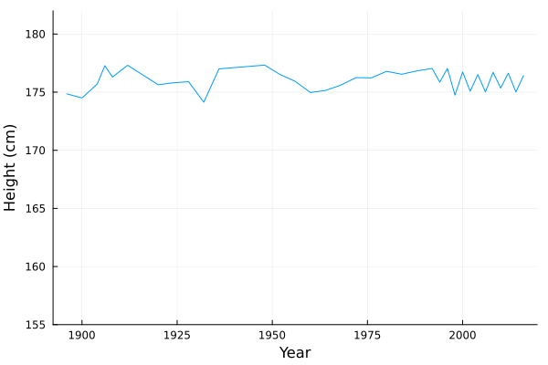

```julia
using Plots
athlete_by_year = groupby(athlete_df, :Year)
height_by_year = combine(athlete_by_year, :Height => mean ∘ skipmissing => :Height)
plot(height_by_year.Year, height_by_year.Height, ylim = [155, 182]; ylabel = "Height (cm)", xlabel = "Year", legend = false)
```

This doesn't show anything interesting. Yet. There are a few confounding factors to eliminate first.

First, there is something going on strange with the years, which started at 4-year increments and changed to 2-year increments. This is due to Winter Olympics moving to a different year to the Summer Olympics in 1994.

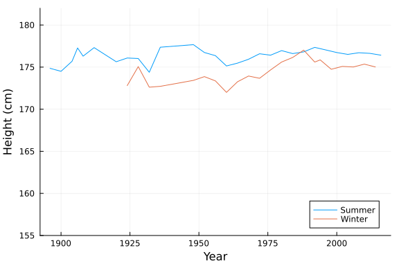

```julia
athlete_by_games = groupby(athlete_df, [:Year, :Season])
height_by_games = combine(athlete_by_games, :Height => mean ∘ skipmissing => :Height)
plot(height_by_games.Year, height_by_games.Height, ylim = [155, 182]; ylabel = "Height (cm)", xlabel = "Year", group = height_by_games.Season, legend = :bottomright)
```

The type of sport might affect the height of the competitors (think basketball players vs jockeys) so it's good to split these groups. Here it seems that winter competitors are slightly shorter than summer competitors.

The second confounding factor is that women have increasingly became a larger fraction of the competitors at the Olympics, so we will split also by gender.

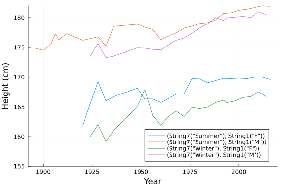

```julia
athlete_by_cohort = groupby(athlete_df, [:Year, :Season, :Sex])
height_by_cohort = combine(athlete_by_cohort, :Height => mean ∘ skipmissing => :Height)
plot(height_by_cohort.Year, height_by_cohort.Height, ylim = [155, 182]; ylabel = "Height (cm)", xlabel = "Year", group = tuple.(height_by_cohort.Season, height_by_cohort.Sex), legend = :bottomright)
```

Whoa! Now we clearly see that heights have trended up at least 5cm since 1900!

What's going on here? I suspect it is a combination of several facts:

1. On average, people born before the end of World War 2 were shorter, due to nutritional changes.
2. Sport has become more elite and competitive over the years, and height may correlate with success in many Olympic sports.
3. Women competitors have become more prevalent over time, reducing the average height of *all* competitors.
4. Similarly, winter competitors may have become more prevalent over time, who appear to be shorter than the summer cohorts.

We can easily verify #3 above.

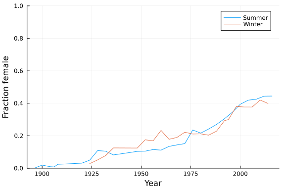

```julia
gender_by_games = combine(athlete_by_games, :Sex => (s -> count(==("F"), s) / length(s)) => :Fraction_Female)
plot(gender_by_games.Year, gender_by_games.Fraction_Female, ylim = [0, 1]; ylabel = "Fraction female", xlabel = "Year", group = gender_by_games.Season, legend = :topright)
```

Note that we could have given up our analysis with the first plot, above, and arrived at completely the wrong conclusion!

Having these tools under your belt is a very useful skill. It is quite common that you need to have the skills to dig under the surface to get a correct understanding of data. It is just as useful to debunk a myth or assumption as it is to find a hitherto unknown correlation.

### Histograms

These are just the means, we can also compare the statistic distribution (for the 2016 games, say):

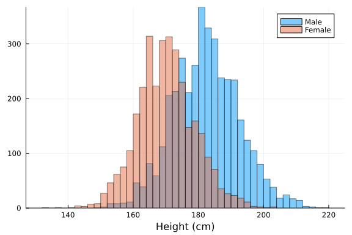

```julia
histogram(collect(skipmissing(athlete_by_cohort[(2016, "Summer", "M")].Height)), xlabel = "Height (cm)", opacity = 0.5, label = "Male")
histogram!(collect(skipmissing(athlete_by_cohort[(2016, "Summer", "F")].Height)), opacity = 0.5, label = "Female")
```

The `histogram` function is useful for identifying features of distributions (e.g. if it is bimodal).

### Further questions

We could analyse this data another hundred ways. Some questions that come to mind are:

- How does team success relate to socioeconomic indicators of their home country, such as GDP per capita? Do richer countries do comparatively better than poorer countries? To do this, we would need to *join* the data with country data.
- Does team success depend on the distance between the host of the Olympics and the home nation? For example, Australia received a lot of medals during the Sydney 2000 Olympics.
- Can we predict how well a team will do at a given Olympics, based on data like above? This is heading in the direction of machine learning.

## Fitting linear models

Here we'll briefly show how to fit linear models to your data using the package **GLM.jl**. A one dimensional linear model may be written

\[ Y = \beta_0 + \beta_1 X + \epsilon \]

where $Y$ is some dependent variable to be predicted, $X$ is the independent variable and $\epsilon$ is some random noise. The task of fitting is to estimate the model parameters $\beta_0$ and $\beta_1$; one may also want to estimate the variance of the noise $\epsilon$. Simple linear models like this (and the multidimensional generalization) can be fit with least squares to give the maximum liklihood estimate of the parameters $\beta$.

Let's look at a simple example from the athletes data

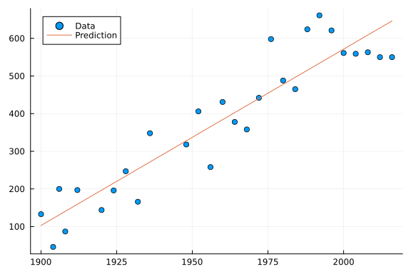

```julia
using GLM, Underscores

df = DataFrame(CSV.File("../data/athlete_events.csv"; missingstring = "NA"))

rowing_by_year = @_ df |>
   groupby(__, [:Year, :Sport]) |>
   combine(__, nrow => :Count) |>
   sort(__, :Year) |>
   filter(:Sport => ==("Rowing"), __)

model = lm(@formula(Count ~ Year), rowing_by_year)

scatter(rowing_by_year.Year, rowing_by_year.Count, label="Data")
plot!(rowing_by_year.Year, predict(model, rowing_by_year), label="Prediction")
```

Q: Is this linear fit a reasonable thing to do? (What's going on after 2000?)

Let's now look at how to fit a multidimensional model using GLM.jl. In the multidimensional case we have several independent variables $X_1, \dots, X_p$ and several dependent variables $Y_1, \dots, Y_n$:

\[ Y_i = \beta_0 + \beta_1 X_{i1} + \beta_2 X_{i2} + \dots \beta_p X_{ip} + \epsilon_i \]

Here's an example of fitting CPU performance for some historical CPUs, taken from the book "Statistics with Julia":

```julia
using RDatasets, Statistics

df = dataset("MASS", "cpus")
df.Freq = map( x->10^9/x , df.CycT)

model = lm(@formula(Perf ~ MMax + Cach + ChMax + Freq), df)
println("n = ", size(df)[1])
println("(Avg,Std) of observed performance: ", (mean(df.Perf),std(df.Perf)))
model
```

```
n = 209
(Avg,Std) of observed performance: (105.61722488038278, 160.83058719907774)
StatsModels.TableRegressionModel{LinearModel{GLM.LmResp{Vector{Float64}}, G
LM.DensePredChol{Float64, LinearAlgebra.CholeskyPivoted{Float64, Matrix{Flo
at64}, Vector{Int64}}}}, Matrix{Float64}}

Perf ~ 1 + MMax + Cach + ChMax + Freq

Coefficients:
───────────────────────────────────────────────────────────────────────────
────────
                    Coef.   Std. Error      t  Pr(>|t|)     Lower 95%     U
pper 95%
───────────────────────────────────────────────────────────────────────────
────────
(Intercept)  -46.5763      7.62382      -6.11    <1e-08  -61.6078      -31.
5447
MMax           0.00841457  0.000639214  13.16    <1e-28    0.00715426    0.
00967489
Cach           0.872508    0.152825      5.71    <1e-07    0.571189      1.
17383
ChMax          0.96736     0.234847      4.12    <1e-04    0.504321      1.
4304
Freq           9.74951e-7  5.5502e-7     1.76    0.0805   -1.1936e-7     2.
06926e-6
───────────────────────────────────────────────────────────────────────────
────────
```

Using the model to predict:

```julia
pred(x) = round(coef(model)'*vcat(1,x), digits = 3)
println("Estimated performance test computers: for computer A: ", pred([32000, 32, 32, 4*10^7]))

# Using the data and the `predict()` function
test_data = DataFrame(
    name  = ["Computer A", "Computer B"],
    MMax  = [32000,        32000],
    Cach  = [32,           16],
    ChMax = [32,           32],
    Freq  = [4*10^7,       6*10^7],
)

println("Estimated performance test computers:")
println(predict(model, test_data))
```

```
Estimated performance test computers: for computer A: 320.564
Estimated performance test computers:
Union{Missing, Float64}[320.56388734263396, 326.10276642540515]
```

Note that GLM stands for "generalized linear model" and the GLM.jl package can fit more general models - specifically those where the left and right hand sides are related by a nonlinear "link function", and where the random noise is not normally distributed.

# Memory management in data workflows

Generally in data heavy workflows we have three rough "sizes" to worry about.

1. Small data: data fits in RAM. Just load it up and process it all at once. We are doing this in this course.
2. Medium data: data is too big for RAM, but it fits on disk. Incrementally load "chunks" from disk, save the results, and load the next chunk, etc - known as "out-of-core" processing. Multiple such steps might be required in a "pipeline". Reading and writing to disk is slower than RAM, and processing might take so long that restarting from scratch (after a fault or power blackout, for example) is not realistic, so you generally need to be able to save and restore your intermediate state, or update your data incrementally. A typical SQL database is in this category, handling the persistence, fault-tolerance and pipelining for you automatically.
3. Big data: data is too big to fit on the hard drive of a single computer. Generally requires a distributed solution for both storage and processing. At this scale, it is "business as usual" for computers to die and hard drives or RAM to corrupt, and you can't have your multi-million-dollar operation brought down by a single rogue bitflip. These days it is common and convenient to use cloud services for these situations - like those provided by Amazon (AWS), Microsoft (Azure) or Google (GCP).

The boundaries between these regimes depends on your computer hardware. As you get step up, the complexity increases rapidly, especially with respect to fault tolerance.

At my previous job with [Fugro](https://www.fugro.com/) we processed petabytes of LiDAR, imagery and positioning data to create a 3D model of the world. We used AWS to store and index the data, as well as process it. The effort in "data engineering" was as much as was required in the "data science". Generally, it pays to have your data sorted out before attempting any higher-order analytics at scale (such as machine learning, below).

[Main MATH2504 Page](https://courses.smp.uq.edu.au/MATH2504/)

Unit 1 | Unit 2 | Unit 3 | Unit 4 | Unit 5 | Unit 6 | Unit 7 | Unit 8

Published from lecture-unit-8.jmd using Weave.jl v0.10.12 on 2025-10-28.